# KNN算法

### K近邻分类器：

> 对于一个被预测的新样本x，K近邻分类器将（在当前的d维空间）找到与该样本x最近的k个样本（来自于训练数据集）（这k个样本称为该样本的k个最近邻）；k个最近邻样本中所占类别数最多的那个类就是被预测样本的类别。

> kNN算法的核心思想是如果一个样本在特征空间中的k个最相邻的样本中的大多数属于某一个类别，则该样本也属于这个类别，并具有这个类别上样本的特性。该方法在确定分类决策上只依据最邻近的一个或者几个样本的类别来决定待分样本所属的类别。 kNN方法在类别决策时，只与极少量的相邻样本有关。由于kNN方法主要靠周围有限的邻近的样本，而不是靠判别类域的方法来确定所属类别的，因此对于类域的交叉或重叠较多的待分样本集来说，kNN方法较其他方法更为适合。

[figure not shown]

### knn算法图解

[figure not shown]

### 程序说明

python 2.7 + ubuntu16 +numpy + pandas + matpltolib

两个数据文件都加了表头行，请读取项目的文件

knn分类器的k=10

### 导入数据

```python
import numpy as np
import pandas as pd
import matplotlib.pyplot as plt
import sklearn
%matplotlib inline

df = pd.read_excel('作业02-dmr_data.xls')
df.head()

df_labels = pd.read_table('作业02-dmr_label.txt')
df_labels.head()
#len(df_labels)
```

|  | L |
| --- | --- |
| 0 | 1 |
| 1 | 1 |
| 2 | 1 |
| 3 | 1 |
| 4 | 1 |

```python
DT = df.get_values()

#labels改为list格式
DT_labels = np.array(df_labels)
#DT_labels1={}
#for i in range(len(DT_labels)):
#    DT_labels1[i] = DT_labels[i][0]

#print(DT_labels1)
```

### 标准化（Z-Score）

(X-mean)/std 计算时对每个属性/每列分别进行。

```python
TT = np.zeros((11,5))
TT
```

```
array([[ 0.,  0.,  0.,  0.,  0.],
       [ 0.,  0.,  0.,  0.,  0.],
       [ 0.,  0.,  0.,  0.,  0.],
       [ 0.,  0.,  0.,  0.,  0.],
       [ 0.,  0.,  0.,  0.,  0.],
       [ 0.,  0.,  0.,  0.,  0.],
       [ 0.,  0.,  0.,  0.,  0.],
       [ 0.,  0.,  0.,  0.,  0.],
       [ 0.,  0.,  0.,  0.,  0.],
       [ 0.,  0.,  0.,  0.,  0.],
       [ 0.,  0.,  0.,  0.,  0.]])
```

```python
#使用sklearn.preprocessing.scale()函数，可以直接将给定数据进行标准化。
from sklearn import preprocessing
DT1 = preprocessing.scale(DT)

#手写by Gao
def ZScore(DT):
    m,n = np.shape(DT)
    DT_n = np.zeros((m,n))
    for i in range(n):
        u = np.mean(DT[:,i])
        s = np.std(DT[:,i])
        DT_n[:,i] = (DT[:,i]-u)/s

    return DT_n

DT1 = ZScore(DT)
DT1
```

```
array([[-0.66475157, -0.98582817, -1.17056407, ..., -0.28619659,
        -0.13653029, -0.31110715],
       [-0.47439765,  3.48916405, -0.51147814, ..., -0.28619659,
        -0.13653029, -0.31110715],
       [ 2.6188535 , -0.373672  ,  2.04247983, ...,  0.03955004,
         2.26055269,  0.27612795],
       ...,
       [-0.30783798, -0.31457933, -0.18193518, ..., -0.28619659,
        -0.13653029, -0.31110715],
       [-0.40301493, -0.30779904, -0.26432092, ..., -0.28619659,
        -0.13653029, -0.31110715],
       [ 0.50116617, -0.0214217 ,  1.05385094, ..., -0.28619659,
        -0.13653029, -0.31110715]])
```

### 0-1标准化函数(将属性缩放到一个指定范围)

```python
#使用sklearn
min_max_scaler = preprocessing.MinMaxScaler()
DT2 = min_max_scaler.fit_transform(DT)

#手写by Gao
def Standard(DT):
    m,n = np.shape(DT)
    DT_n = np.zeros((m,n))
    for i in range(n):
        Max = max(DT[:,i])
        Min = min(DT[:,i])
        DT_n[:,i] = (DT[:,i]-Min)/(Max-Min)
    return DT_n

DT2 = Standard(DT)
DT2
```

```
array([[ 0.        ,  0.        ,  0.        , ...,  0.        ,
         0.        ,  0.        ],
       [ 0.02867384,  0.99337749,  0.14035088, ...,  0.        ,
         0.        ,  0.        ],
       [ 0.49462366,  0.13588899,  0.68421053, ...,  0.05035971,
         0.25179856,  0.10791367],
       ...,
       [ 0.05376344,  0.14900662,  0.21052632, ...,  0.        ,
         0.        ,  0.        ],
       [ 0.03942652,  0.15051174,  0.19298246, ...,  0.        ,
         0.        ,  0.        ],
       [ 0.17562724,  0.21408298,  0.47368421, ...,  0.        ,
         0.        ,  0.        ]])
```

### KNN算法实现

```python
from numpy import *
import operator

def knn(inX, dataSet, labels, k):
    dataSetSize = dataSet.shape[0]
    #print dataSetSize
    diffMat = tile(inX, (dataSetSize,1)) - dataSet
    #print diffMat
    sqDiffMat = diffMat**2
    #print sqDiffMat
    sqDistances = sqDiffMat.sum(axis=1)
    #print sqDistances
    distances = sqDistances** 0.5
    #print distances.shape
    sortedDistIndicies = distances.argsort()
    #print(sortedDistIndicies)
    classCount={}
    #print type(labels)

    for i in range(k):
        voteIlabel = labels[sortedDistIndicies[i]]
        #print(sortedDistIndicies[i])
        classCount[voteIlabel]=classCount.get(voteIlabel,0)+1
    sortedClassCount = sorted(classCount.iteritems(),key=operator.itemgetter(1),reverse=True)
    return sortedClassCount[0][0]


#test
#group,labels=createDataSet()
#print type(labels)

#print(knn([1.00,0.00,1.00,0.00,0.26,0.00,0.00,0.00,0.00,0.00,0.00],DT,DT_labels1,3))
#print(type(DT_labels[1]))
```

## 交叉验证

> 交叉验证(Cross-Validation): 有时亦称循环估计， 是一种统计学上将数据样本切割成较小子集的实用方法。于是可以先在一个子集上做分析， 而其它子集则用来做后续对此分析的确认及验证。 一开始的子集被称为训练集。而其它的子集则被称为验证集或测试集。

## K-fold Cross Validation(k折叠)

- 方法：将原始数据分成K组(一般是均分),将每个子集数据分别做一次验证集,其余的K-1组子集数据作为训练集,这样会得到K个模型,用这K个模型最终的验证集的分类准确率的平均数作为此K-CV下分类器的性能指标.K一般大于等于2,实际操作时一般从3开始取,只有在原始数据集合数据量小的时候才会尝试取2. 而K-CV 的实验共需要建立 k 个models，并计算 k 次 test sets 的平均辨识率。在实作上，k 要够大才能使各回合中的 训练样本数够多，一般而言 k=10 (作为一个经验参数)算是相当足够了。
- 优点：K-CV可以有效的避免过学习以及欠学习状态的发生,最后得到的结果也比较具有说服性.
- 缺点：K值选取上

## Leave-One-Out Cross Validation(留一)

- 方法：如果设原始数据有N个样本,那么留一就是N-CV,即每个样本单独作为验证集,其余的N-1个样本作为训练集,所以留一会得到N个模型,用这N个模型最终的验证集的分类准确率的平均数作为此下LOO-CV分类器的性能指标.
- 优点：相比于前面的K-CV,留一有两个明显的优点：
  - a.每一回合中几乎所有的样本皆用于训练模型,因此最接近原始样本的分布,这样评估所得的结果比较可靠。
  - b. 实验过程中没有随机因素会影响实验数据,确保实验过程是可以被复制的.
- 缺点：计算成本高,因为需要建立的模型数量与原始数据样本数量相同,当原始数据样本数量相当多时,LOO-CV在实作上便有困难几乎就是不显示,除非每次训练分类器得到模型的速度很快,或是可以用并行化计算减少计算所需的时间。

### 10折交叉验证

```python
#k-fold Cross Validation
#KFold
from sklearn.model_selection import KFold
def kfold(DT,DT_labels,k):
    kf = KFold(n_splits=10) #分成几个组
    kf.get_n_splits(DT)
    DT_labels = np.array(DT_labels)
    #第几个测试集
    count1 = 0
    #总命中数目/样本总数
    count2 = 0
    #存放分类精度
    a=[]
    for train_index,test_index in kf.split(DT):
        #print("Train Index:",train_index,",Test Index:",test_index)
        X_train,X_test=DT[train_index],DT[test_index]
        y_train,y_test=DT_labels[train_index],DT_labels[test_index]

        y_train1={}
        for i in range(len(y_train)):
            y_train1[i] = y_train[i][0]

        count = 0
        for i in range(len(y_test)):
            y_labels = knn(X_test[i].tolist(),X_train,y_train1,k)
            if y_labels == y_test[i] :
                count=count +1
        print("测试集合"+str(count1)+"分类精度为"+str(count*1.0/len(y_test)))
        a.append(count*1.0/len(y_test))
        count2 = count2 +count
        count1 = count1 +1

    print("k="+str(k)+"时，10折交叉验证的分类精度为："+str(count2*1.0/len(DT1)))
    return (a,count2*1.0/len(DT1))
```

### 10折交叉验证分布图(k=10,DT1(Z-score))

```python
print(DT1)

print(DT2)
```

```
[[-0.66475157 -0.98582817 -1.17056407 ..., -0.28619659 -0.13653029
  -0.31110715]
 [-0.47439765  3.48916405 -0.51147814 ..., -0.28619659 -0.13653029
  -0.31110715]
 [ 2.6188535  -0.373672    2.04247983 ...,  0.03955004  2.26055269
   0.27612795]
 ...,
 [-0.30783798 -0.31457933 -0.18193518 ..., -0.28619659 -0.13653029
  -0.31110715]
 [-0.40301493 -0.30779904 -0.26432092 ..., -0.28619659 -0.13653029
  -0.31110715]
 [ 0.50116617 -0.0214217   1.05385094 ..., -0.28619659 -0.13653029
  -0.31110715]]
[[ 0.          0.          0.         ...,  0.          0.          0.        ]
 [ 0.02867384  0.99337749  0.14035088 ...,  0.          0.          0.        ]
 [ 0.49462366  0.13588899  0.68421053 ...,  0.05035971  0.25179856
   0.10791367]
 ...,
 [ 0.05376344  0.14900662  0.21052632 ...,  0.          0.          0.        ]
 [ 0.03942652  0.15051174  0.19298246 ...,  0.          0.          0.        ]
 [ 0.17562724  0.21408298  0.47368421 ...,  0.          0.          0.        ]]
```

```
测试集合0分类精度为0.4
测试集合1分类精度为0.0
测试集合2分类精度为0.3
测试集合3分类精度为0.5
测试集合4分类精度为0.8
测试集合5分类精度为0.3
测试集合6分类精度为0.333333333333
测试集合7分类精度为0.333333333333
测试集合8分类精度为0.444444444444
测试集合9分类精度为0.333333333333
k=10时，10折交叉验证的分类精度为：0.375
测试集合0分类精度为0.3
测试集合1分类精度为0.0
测试集合2分类精度为0.2
测试集合3分类精度为0.5
测试集合4分类精度为0.7
测试集合5分类精度为0.3
测试集合6分类精度为0.333333333333
测试集合7分类精度为0.444444444444
测试集合8分类精度为0.555555555556
测试集合9分类精度为0.222222222222
k=10时，10折交叉验证的分类精度为：0.354166666667
```

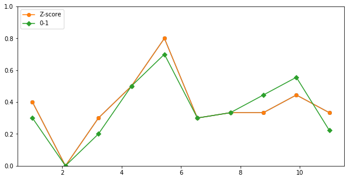

```python
import matplotlib.pyplot as plt

#kfold
(a,g) = kfold(DT1,DT_labels,10)
P_Count = a
(b,g) = kfold(DT2,DT_labels,10)
P_Count1 = b

count1 = len(a)

X = np.linspace(1,count1+1,count1)
plt.figure(figsize=(10,5))
plt.plot(X, P_Count, '-o');
plt.ylim([0,1])
plt.plot(X, P_Count, '-o',label="Z-score")
plt.plot(X, P_Count1, '-D',label="0-1")
plt.legend(loc='upper left');
```

```python
#LeaveOneGroupOut其实就是k=N-1的ｋ折交叉验证
#KFold
from sklearn.model_selection import KFold
def leaveone(DT,DT_labels,k):
    group=len(DT)-1 #分成几个组
    kf = KFold(n_splits=group) #分成几个组
    kf.get_n_splits(DT)
    DT_labels = np.array(DT_labels)
    #存放分类精度
    b=[]
    #第几个测试集
    count1 = 0
    #总命中数目/样本总数
    count2 = 0
    for train_index,test_index in kf.split(DT):
        X_train,X_test=DT[train_index],DT[test_index]
        y_train,y_test=DT_labels[train_index],DT_labels[test_index]

        #格式转换
        y_train1={}
        for i in range(len(y_train)):
            y_train1[i] = y_train[i][0]

        count = 0
        for i in range(len(y_test)):
            y_labels = knn(X_test[i].tolist(),X_train,y_train1,k)
            if y_labels == y_test[i] :
                count=count +1
        print("测试集合"+str(count1)+"分类精度为"+str(count*1.0/len(y_test)))
        b.append(count*1.0/len(y_test))
        count2 = count2 +count
        count1 = count1 +1

    print("k="+str(k)+"时，留一法的分类精度为："+str(count2*1.0/len(DT)))
    return (b,count2*1.0/len(DT))
```

### 留一法分布图

```
测试集合0分类精度为0.5
测试集合1分类精度为1.0
测试集合2分类精度为0.0
测试集合3分类精度为1.0
测试集合4分类精度为1.0
测试集合5分类精度为1.0
测试集合6分类精度为1.0
测试集合7分类精度为1.0
测试集合8分类精度为1.0
测试集合9分类精度为0.0
测试集合10分类精度为0.0
测试集合11分类精度为0.0
测试集合12分类精度为0.0
测试集合13分类精度为1.0
测试集合14分类精度为0.0
测试集合15分类精度为0.0
测试集合16分类精度为1.0
测试集合17分类精度为1.0
测试集合18分类精度为0.0
测试集合19分类精度为0.0
测试集合20分类精度为1.0
测试集合21分类精度为0.0
测试集合22分类精度为1.0
测试集合23分类精度为1.0
测试集合24分类精度为0.0
测试集合25分类精度为0.0
测试集合26分类精度为1.0
测试集合27分类精度为1.0
测试集合28分类精度为0.0
测试集合29分类精度为0.0
测试集合30分类精度为1.0
测试集合31分类精度为1.0
测试集合32分类精度为0.0
测试集合33分类精度为1.0
测试集合34分类精度为1.0
测试集合35分类精度为0.0
测试集合36分类精度为1.0
测试集合37分类精度为1.0
测试集合38分类精度为0.0
测试集合39分类精度为0.0
```

[output cut: 137 more lines]

```
测试集合81分类精度为0.0
测试集合82分类精度为1.0
测试集合83分类精度为1.0
测试集合84分类精度为1.0
测试集合85分类精度为1.0
测试集合86分类精度为1.0
测试集合87分类精度为1.0
测试集合88分类精度为0.0
测试集合89分类精度为0.0
测试集合90分类精度为0.0
测试集合91分类精度为1.0
测试集合92分类精度为1.0
测试集合93分类精度为1.0
测试集合94分类精度为0.0
k=10时，留一法的分类精度为：0.53125
```

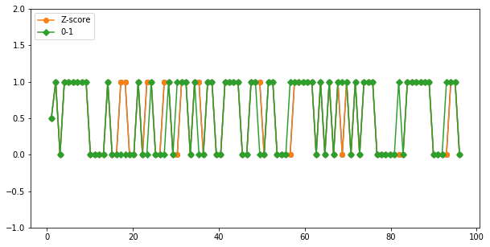

```python
import matplotlib.pyplot as plt

#leaveone
(c,g) = leaveone(DT1,DT_labels,10)
P_Count = c
(d,g) = leaveone(DT2,DT_labels,10)
P_Count1 = d

count1 = len(c)

X = np.linspace(1,count1+1,count1)
plt.figure(figsize=(10,5))
plt.plot(X, P_Count, '-o');
plt.ylim([-1,2])
plt.plot(X, P_Count, '-o',label="Z-score")
plt.plot(X, P_Count1, '-D',label="0-1")
plt.legend(loc='upper left');
```

```
测试集合0分类精度为0.6
测试集合1分类精度为0.1
测试集合2分类精度为0.4
测试集合3分类精度为0.4
测试集合4分类精度为0.6
测试集合5分类精度为0.6
测试集合6分类精度为0.666666666667
测试集合7分类精度为0.555555555556
测试集合8分类精度为0.555555555556
测试集合9分类精度为0.111111111111
k=5时，10折交叉验证的分类精度为：0.458333333333
测试集合0分类精度为0.0
测试集合1分类精度为1.0
测试集合2分类精度为0.0
测试集合3分类精度为1.0
测试集合4分类精度为1.0
测试集合5分类精度为1.0
测试集合6分类精度为1.0
测试集合7分类精度为1.0
测试集合8分类精度为1.0
测试集合9分类精度为0.0
测试集合10分类精度为0.0
测试集合11分类精度为0.0
测试集合12分类精度为0.0
测试集合13分类精度为1.0
测试集合14分类精度为0.0
测试集合15分类精度为0.0
测试集合16分类精度为1.0
测试集合17分类精度为1.0
测试集合18分类精度为0.0
测试集合19分类精度为0.0
测试集合20分类精度为1.0
测试集合21分类精度为0.0
测试集合22分类精度为0.0
测试集合23分类精度为1.0
测试集合24分类精度为0.0
测试集合25分类精度为0.0
测试集合26分类精度为1.0
测试集合27分类精度为1.0
测试集合28分类精度为0.0
```

[output cut: 375 more lines]

```
测试集合83分类精度为1.0
测试集合84分类精度为1.0
测试集合85分类精度为1.0
测试集合86分类精度为1.0
测试集合87分类精度为1.0
测试集合88分类精度为1.0
测试集合89分类精度为0.0
测试集合90分类精度为1.0
测试集合91分类精度为1.0
测试集合92分类精度为1.0
测试集合93分类精度为1.0
测试集合94分类精度为1.0
k=20时，留一法的分类精度为：0.552083333333
[0.4583333333333333, 0.375, 0.4166666666666667, 0.4375]
[0.53125, 0.5416666666666666, 0.5416666666666666, 0.5520833333333334]
```

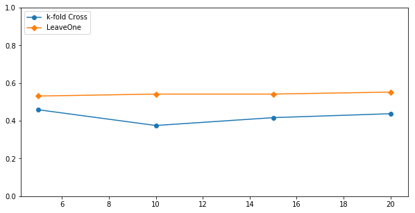

```python
import matplotlib.pyplot as plt
#DT1
listDT1 = []
listDT2 = []
i=5
k = 20

while i < k+1:
    (a,g1) = kfold(DT1,DT_labels,i)
    listDT1.append(g1)
    (c,g2) = leaveone(DT1,DT_labels,i)
    listDT2.append(g2)
    i = i+5

P_Count = listDT1
P_Count1 = listDT2
X = np.linspace(5,20,4)
plt.figure(figsize=(10,5))
plt.ylim([0,1])
plt.plot(X, P_Count, '-o',label="k-fold Cross")
plt.plot(X, P_Count1, '-D',label="LeaveOne")
plt.legend(loc='upper left');
```

```
测试集合0分类精度为0.6
测试集合1分类精度为0.1
测试集合2分类精度为0.3
测试集合3分类精度为0.4
测试集合4分类精度为0.5
测试集合5分类精度为0.6
测试集合6分类精度为0.777777777778
测试集合7分类精度为0.555555555556
测试集合8分类精度为0.444444444444
测试集合9分类精度为0.222222222222
k=5时，10折交叉验证的分类精度为：0.447916666667
测试集合0分类精度为0.0
测试集合1分类精度为1.0
测试集合2分类精度为0.0
测试集合3分类精度为1.0
测试集合4分类精度为1.0
测试集合5分类精度为1.0
测试集合6分类精度为1.0
测试集合7分类精度为1.0
测试集合8分类精度为1.0
测试集合9分类精度为0.0
测试集合10分类精度为0.0
测试集合11分类精度为0.0
测试集合12分类精度为0.0
测试集合13分类精度为1.0
测试集合14分类精度为0.0
测试集合15分类精度为0.0
测试集合16分类精度为1.0
测试集合17分类精度为1.0
测试集合18分类精度为0.0
测试集合19分类精度为0.0
测试集合20分类精度为1.0
测试集合21分类精度为0.0
测试集合22分类精度为0.0
测试集合23分类精度为1.0
测试集合24分类精度为0.0
测试集合25分类精度为0.0
测试集合26分类精度为1.0
测试集合27分类精度为0.0
测试集合28分类精度为0.0
```

[output cut: 375 more lines]

```
测试集合83分类精度为1.0
测试集合84分类精度为1.0
测试集合85分类精度为1.0
测试集合86分类精度为1.0
测试集合87分类精度为1.0
测试集合88分类精度为1.0
测试集合89分类精度为1.0
测试集合90分类精度为1.0
测试集合91分类精度为1.0
测试集合92分类精度为1.0
测试集合93分类精度为1.0
测试集合94分类精度为1.0
k=20时，留一法的分类精度为：0.552083333333
[0.4479166666666667, 0.3541666666666667, 0.4270833333333333, 0.4270833333333333]
[0.5, 0.53125, 0.53125, 0.5520833333333334]
```

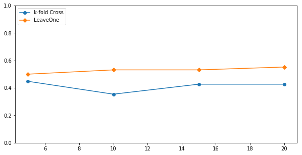

```python
import matplotlib.pyplot as plt
#DT2
listDT1 = []
listDT2 = []
i=5
k = 20

while i < k+1:
    (a,g1) = kfold(DT2,DT_labels,i)
    listDT1.append(g1)
    (c,g2) = leaveone(DT2,DT_labels,i)
    listDT2.append(g2)
    i = i+5

print(listDT1)
print(listDT2)

P_Count = listDT1
P_Count1 = listDT2
X = np.linspace(5,20,4)
plt.figure(figsize=(10,5))
plt.ylim([0,1])
plt.plot(X, P_Count, '-o',label="k-fold Cross")
plt.plot(X, P_Count1, '-D',label="LeaveOne")
plt.legend(loc='upper left');
```